# generating tumor deconvolution training data from SC experiment

Tom Snir

January 27, 2019

A short summary of the data, taken from https://support.10xgenomics.com/single-cell-gene-expression/datasets/3.0.0/malt_10k_protein_v3

10k Cells from a MALT Tumor - Gene Expression and Cell Surface Protein Single Cell Gene Expression Dataset by Cell Ranger 3.0.0 Cells from a dissociated Extranodal Marginal Zone B-Cell Tumor (MALT: Mucosa-Associated Lymphoid Tissue) stained with TotalSeq-B antibodies.

- 8,412 cells detected
- Sequenced on Illumina NovaSeq with approximately 32,000 reads per cell
- 28bp read1 (16bp Chromium barcode and 12bp UMI), 91bp read2 (transcript), and 8bp I7 sample barcode
- run with –expect-cells=10000
- This dataset was generated using a pre-release set of TotalSeq-B antibodies. The barcode sequences have since changed. Please refer to https://www.biolegend.com/totalseq for the latest conjugated barcode information.

To maintain donor anonymity, sequence data for this sample is not currently available.

The below analysis was done based on the following tutorials: https://davetang.org/muse/2017/08/01/getting-started-seurat/ https://hemberg-lab.github.io/scRNA.seq.course/seurat-chapter.html https://satijalab.org/seurat/pbmc3k_tutorial_v3.html

Load the libraries and the data

```r
library(Seurat)
library(dplyr)
library(Matrix)

setwd("C:/Users/Tom Snir/Desktop/Dani/10X/malt_10k_filtered")

malt_filtered <- Read10X("C:/Users/Tom Snir/Desktop/Dani/10X/malt_10k_filtered")
#malt.data <- CreateSeuratObject(raw.data = malt_raw)
```

Before converting the raw data to a Seurat object, we’ll do some basic QC filtering.

```r
dim(malt_filtered) #There are 8412 cells and 33,555 genes in the dataset.
```

```
## [1] 33555  8412
```

```r
malt_filtered[1:6, 1:6] #Looking if the data looks as expected
```

```
## 6 x 6 sparse Matrix of class "dgTMatrix"
##             AAACCCAAGAGGCGGA AAACCCAAGCGCCTTG AAACCCAAGTCTGCAT
## MIR1302-2HG                .                .                .
## FAM138A                    .                .                .
## OR4F5                      .                .                .
## AL627309.1                 .                .                .
## AL627309.3                 .                .                .
## AL627309.2                 .                .                .
##             AAACCCACACCATAAC AAACCCAGTCTCTCCA AAACCCATCACCTGTC
## MIR1302-2HG                .                .                .
## FAM138A                    .                .                .
## OR4F5                      .                .                .
## AL627309.1                 .                .                .
## AL627309.3                 .                .                .
## AL627309.2                 .                .                .
```

```r
summary(colSums(malt_filtered)) #looking at the distribution of gene expression per cell
```

```
##    Min. 1st Qu.  Median    Mean 3rd Qu.    Max.
##     760    4447    6442    9144   11339  371792
```

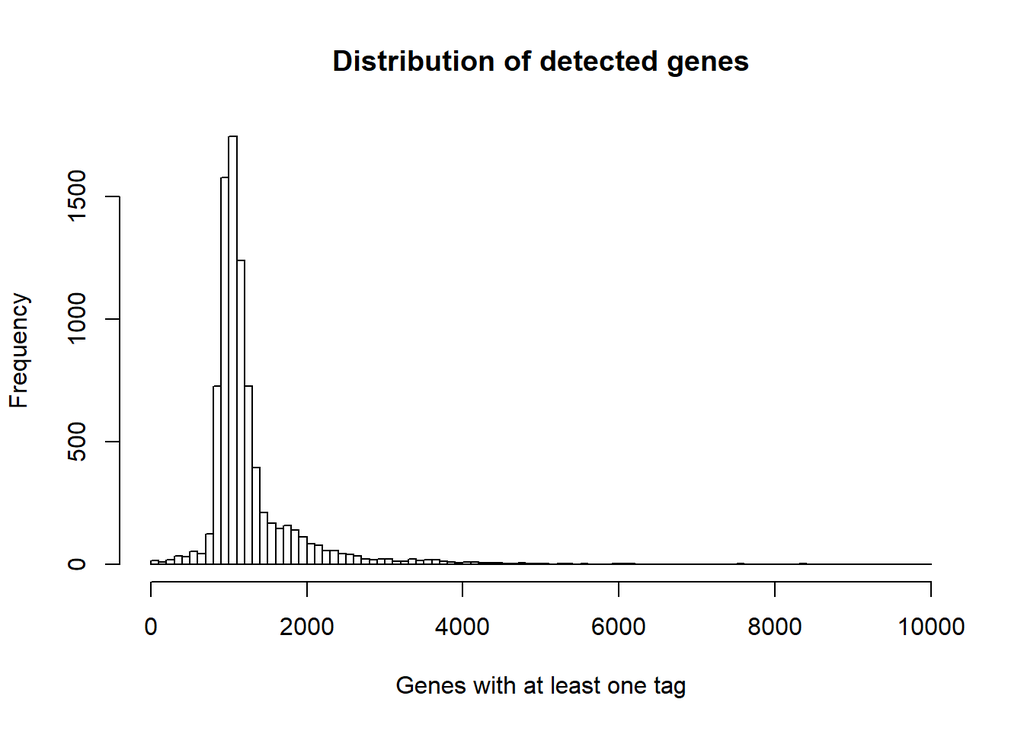

```r
# check how many genes have at least one transcript in each cell
at_least_one <- apply(malt_filtered, 2, function(x) sum(x>0))
hist(at_least_one, breaks = 100,
     main = "Distribution of detected genes",
     xlab = "Genes with at least one tag")
```

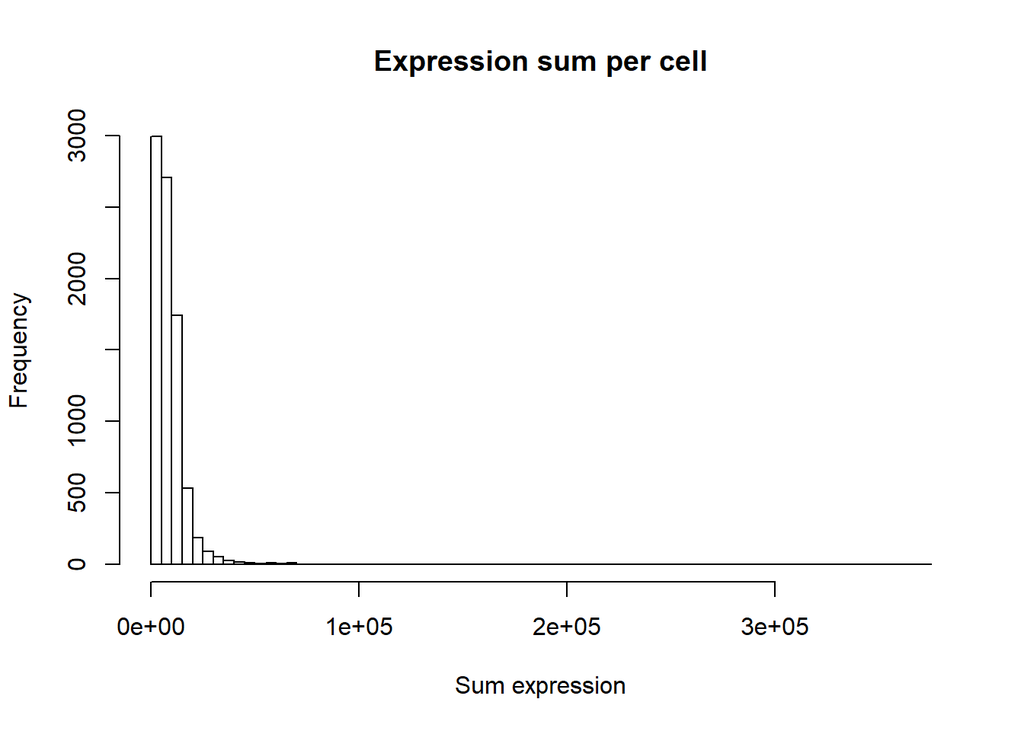

```r
hist(colSums(malt_filtered),
     breaks = 100, main = "Expression sum per cell",
     xlab = "Sum expression")
```

```r
malt.data <- CreateSeuratObject(raw.data = malt_filtered,
                           min.cells = 8,
                           min.genes = 200,
                           project = "malt_filtered")

malt.data
```

```
## An object of class seurat in project malt_filtered
##  16046 genes across 8386 samples.
```

We only lost a few cells but about half of the genes, meaning that a lot of genes were only expressed in a handfull of cells. Since we still have a good number of genes, I will continue with these QC constraints and consider changing these later on.

Next we’ll look at the distribution of number of genes and number of umis, and filter out outliers.

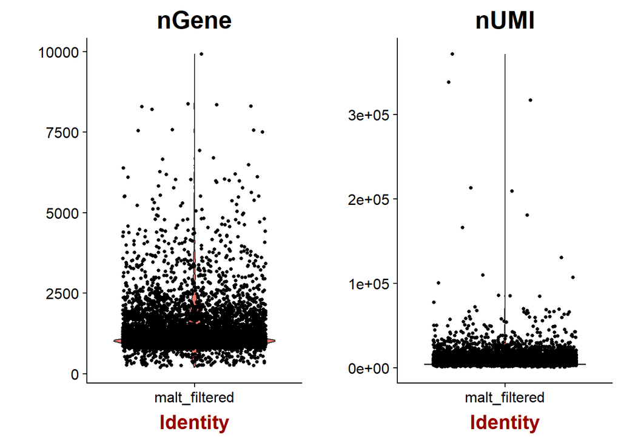

```r
VlnPlot(object = malt.data,
        features.plot = c("nGene", "nUMI"),
        nCol = 2)
```

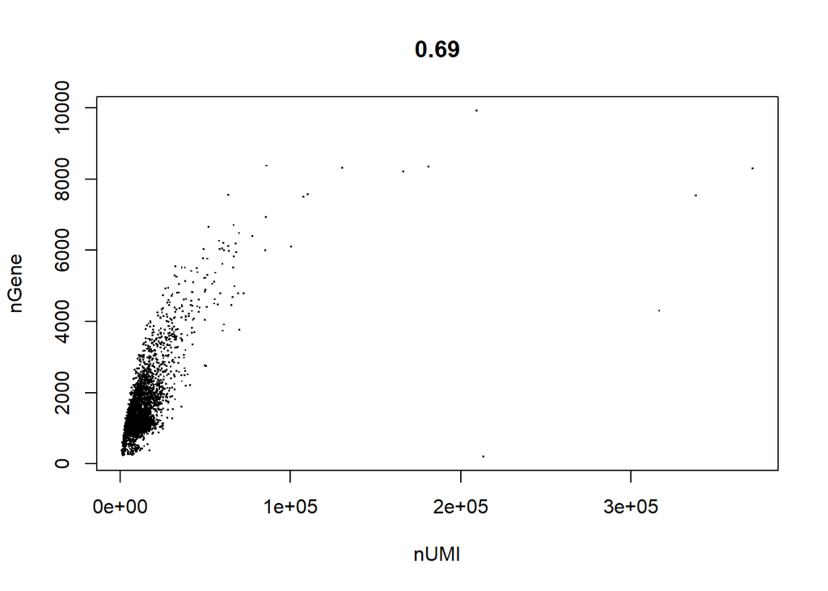

```r
GenePlot(object = malt.data, gene1 = "nUMI", gene2 = "nGene", pch.use = '.') #each gene should have 1 UMI.
```

From the above plots it seems we should remove a few outliers,

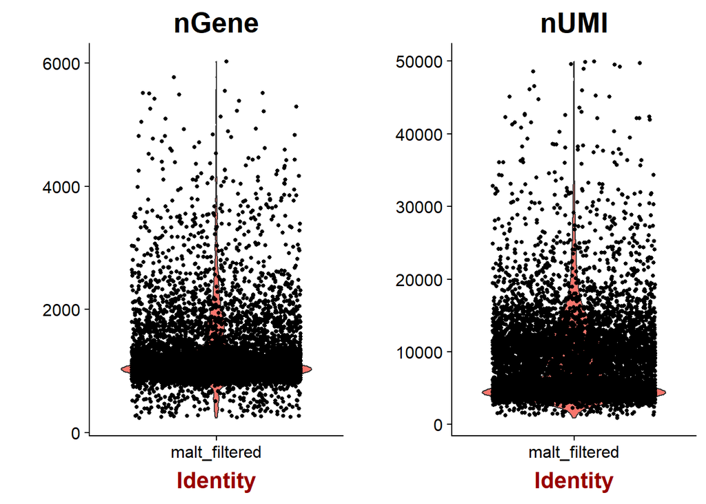

```r
malt.data <- FilterCells(object = malt.data,
                    subset.names = c("nGene", "nUMI"),
                    high.thresholds = c(7500, 50000))


VlnPlot(object = malt.data,
        features.plot = c("nGene", "nUMI"),
        nCol = 2)
```

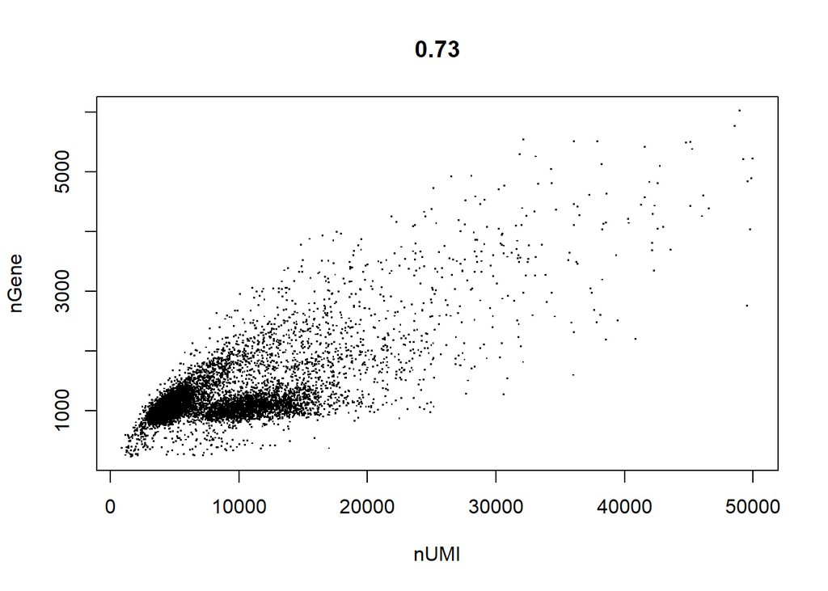

```r
GenePlot(object = malt.data, gene1 = "nUMI", gene2 = "nGene", pch.use = '.')
```

Not amazing, but I will continue with this subset of the data for now (not sure why the nGene to nUMI is so spread out, this is not typical)

Normalize the data, compare before and after:

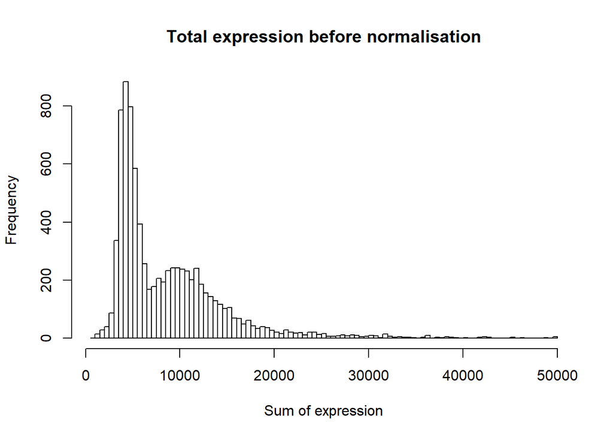

```r
hist(colSums(malt.data@data),
     breaks = 100,
     main = "Total expression before normalisation",
     xlab = "Sum of expression")
```

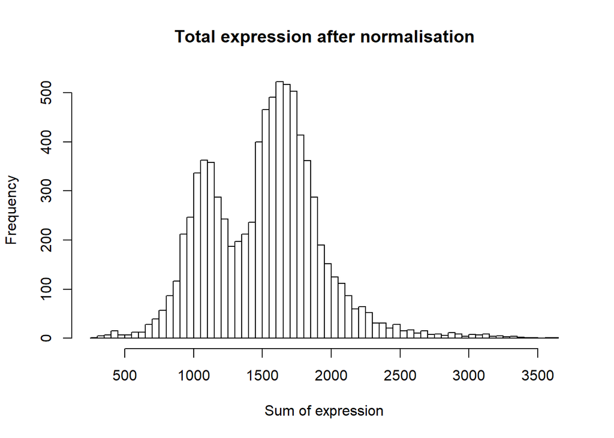

```r
malt.norm <- NormalizeData(object = malt.data,
                      normalization.method = "LogNormalize",
                      scale.factor = 1e4)

hist(colSums(malt.norm@data),
     breaks = 100,
     main = "Total expression after normalisation",
     xlab = "Sum of expression")
```

Next we’re looking for variable genes in the data

```r
malt.norm <- FindVariableGenes(
    object = malt.norm,
    mean.function = ExpMean,
    dispersion.function = LogVMR,
    x.low.cutoff = 0.0125,
    x.high.cutoff = 3,
    y.cutoff = 0.5
)
```

[figure not shown]

```r
length(malt.norm@var.genes)
```

```
## [1] 1295
```

There are 1295 variable genes (using Seurat’s default parameters anyway). This is a large enough number to expect enough marker genes for Dani’s Tumor Deconvolution.

Removing confounders (Seurat constructs linear models to predict gene expression based on user-defined variables to help remove unwanted sources of variation. The idea is that confounding factors, e.g. batch effects and cell cycle stage, affect the observed gene expression patterns and one should adjust for these factors to infer the “correct” gene expression pattern.)

```r
malt.norm <- ScaleData(
    object = malt.norm,
    vars.to.regress = c("nUMI")
)
```

```
##
## Time Elapsed:  21.1982970237732 secs
```

```
## Scaling data matrix
```

```r
#done with QC, so saving the data set

malt <- malt.norm
```

PCA and visualization

```r
malt <- RunPCA(
    object = malt,
    pc.genes = malt@var.genes,
    do.print = TRUE,
    pcs.print = 1:5,
    genes.print = 5
)
```

```
## [1] "PC1"
## [1] "IL7R"  "TRBC1" "ANXA1" "ITM2A" "IL32"
## [1] ""
## [1] "HLA-DRB1" "HLA-DQA1" "MS4A1"    "IGHM"     "HLA-DQB1"
## [1] ""
## [1] ""
## [1] "PC2"
## [1] "YBX3"    "IGHD"    "BCL11A"  "TMEM123" "GRASP"
## [1] ""
## [1] "RGCC"      "DUSP4"     "TNFRSF13B" "IGHA1"     "S100A4"
## [1] ""
## [1] ""
## [1] "PC3"
## [1] "CST3"   "TYROBP" "LYZ"    "CEBPD"  "FCER1G"
## [1] ""
## [1] "PCLAF" "RGS13" "MKI67" "CDK1"  "AURKB"
## [1] ""
## [1] ""
## [1] "PC4"
## [1] "CD69"  "CD55"  "DUSP1" "BANK1" "IGHM"
## [1] ""
## [1] "PCLAF" "RGS13" "CDK1"  "MKI67" "GCHFR"
## [1] ""
## [1] ""
## [1] "PC5"
## [1] "CST3"   "LYZ"    "LGALS2" "GSN"    "AIF1"
## [1] ""
## [1] "DUSP2" "CCL5"  "NKG7"  "GZMK"  "CST7"
## [1] ""
## [1] ""
```

```r
PrintPCA(object = malt, pcs.print = 1:5, genes.print = 5, use.full = FALSE)
```

```
## [1] "PC1"
## [1] "IL7R"  "TRBC1" "ANXA1" "ITM2A" "IL32"
## [1] ""
## [1] "HLA-DRB1" "HLA-DQA1" "MS4A1"    "IGHM"     "HLA-DQB1"
## [1] ""
## [1] ""
## [1] "PC2"
## [1] "YBX3"    "IGHD"    "BCL11A"  "TMEM123" "GRASP"
## [1] ""
## [1] "RGCC"      "DUSP4"     "TNFRSF13B" "IGHA1"     "S100A4"
## [1] ""
## [1] ""
## [1] "PC3"
## [1] "CST3"   "TYROBP" "LYZ"    "CEBPD"  "FCER1G"
## [1] ""
## [1] "PCLAF" "RGS13" "MKI67" "CDK1"  "AURKB"
## [1] ""
## [1] ""
## [1] "PC4"
## [1] "CD69"  "CD55"  "DUSP1" "BANK1" "IGHM"
## [1] ""
## [1] "PCLAF" "RGS13" "CDK1"  "MKI67" "GCHFR"
## [1] ""
## [1] ""
## [1] "PC5"
## [1] "CST3"   "LYZ"    "LGALS2" "GSN"    "AIF1"
## [1] ""
## [1] "DUSP2" "CCL5"  "NKG7"  "GZMK"  "CST7"
## [1] ""
## [1] ""
```

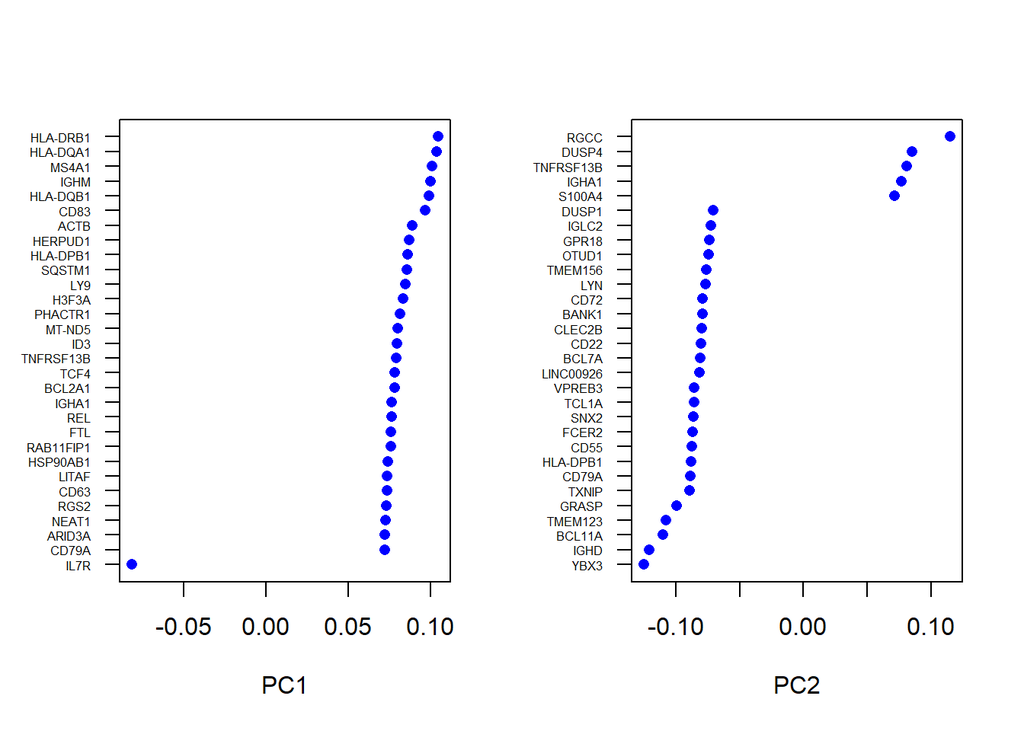

```r
VizPCA(object = malt, pcs.use = 1:2)
```

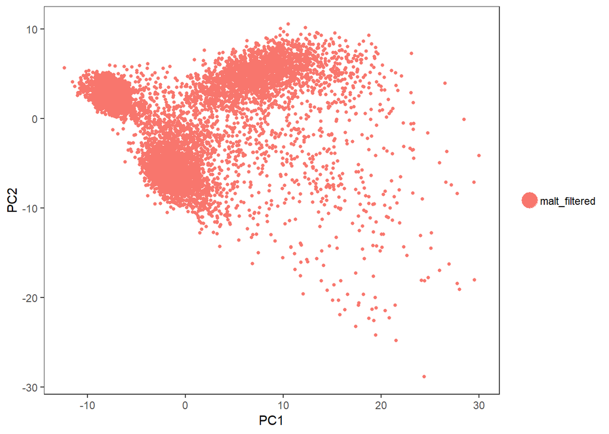

```r
PCAPlot(object = malt, dim.1 = 1, dim.2 = 2)
```

PC1 looks like just the expression of IL7R, a receptor for interleukin 7. The function of this receptor requires the interleukin 2 receptor, gamma chain (IL2RG), which is a common gamma chain shared by the receptors of various cytokines, including interleukins 2, 4, 7, 9, and 15. This protein has been shown to play a critical role in V(D)J recombination during lymphocyte development.

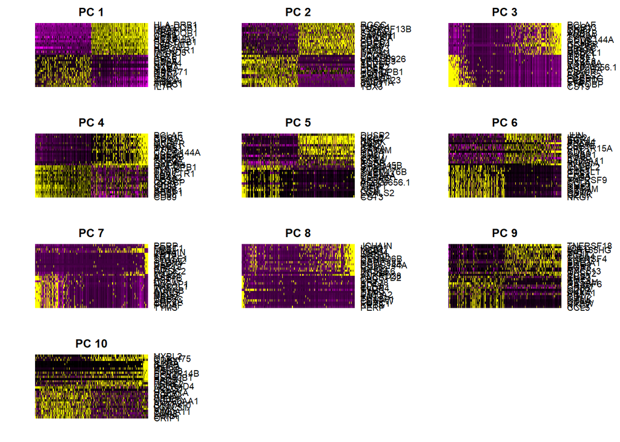

```r
PCHeatmap(
    object = malt,
    pc.use = 1:10,
    cells.use = 500,
    do.balanced = TRUE,
    label.columns = FALSE,
    use.full = FALSE
)
```

Here we try to see how many PCs truly contribute to the analysis

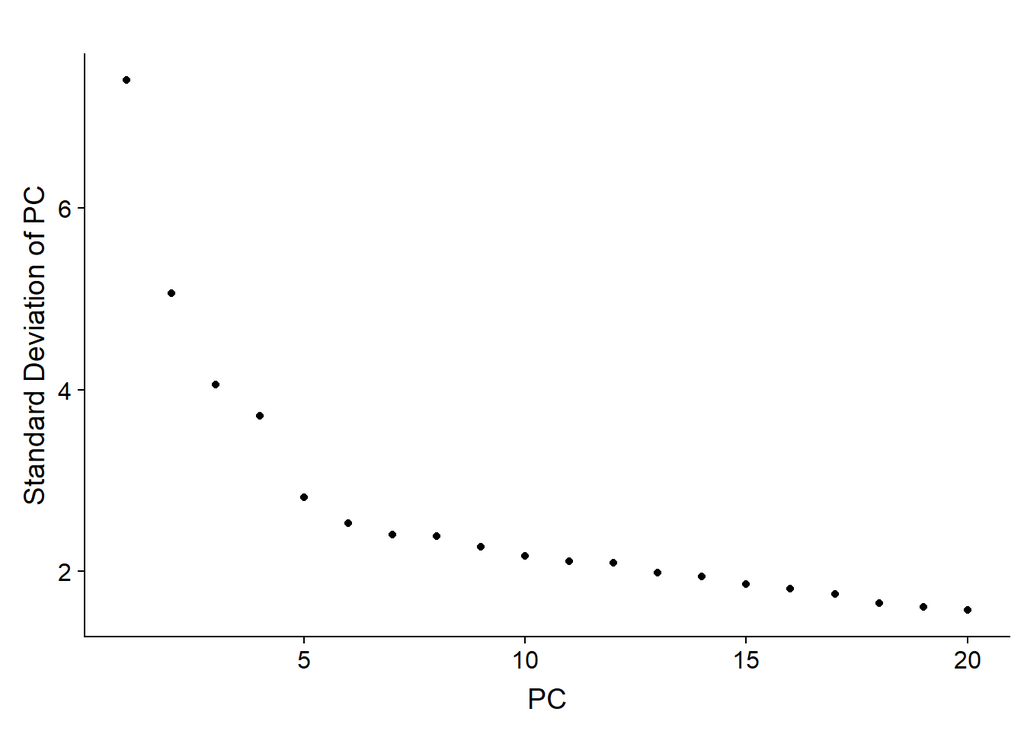

```r
PCElbowPlot(object = malt)
```

I would say that up to PC 17 even we still see some contribution to the variance of the data.

```r
malt <- FindClusters(
    object = malt,
    reduction.type = "pca",
    dims.use = 1:17,
    resolution = 0.6,
    print.output = 0,
    save.SNN = TRUE
)

PrintFindClustersParams(object = malt)
```

```
## Parameters used in latest FindClusters calculation run on: 2019-01-28 15:56:51
## =============================================================================
## Resolution: 0.6
## -----------------------------------------------------------------------------
## Modularity Function    Algorithm         n.start         n.iter
##      1                   1                 100             10
## -----------------------------------------------------------------------------
## Reduction used          k.param          prune.SNN
##      pca                 30                0.0667
## -----------------------------------------------------------------------------
## Dims used in calculation
## =============================================================================
## 1 2 3 4 5 6 7 8 9 10 11 12 13 14 15 16 17
```

Clustering:

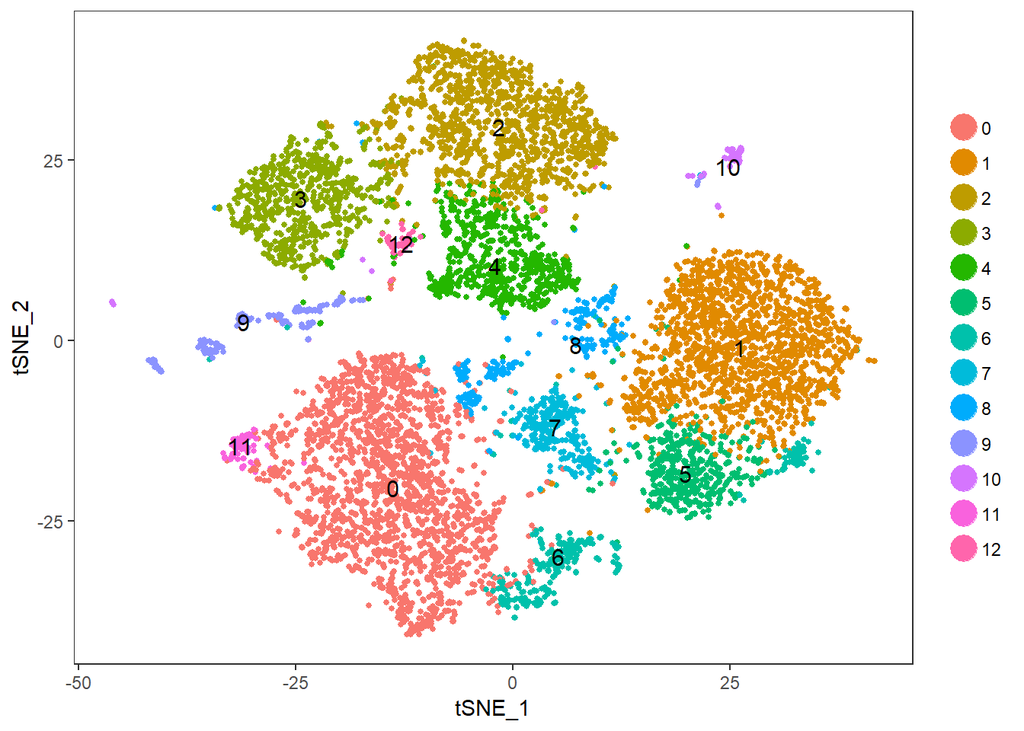

```r
malt <- RunTSNE(
    object = malt,
    dims.use = 1:17,
    do.fast = TRUE
)
TSNEPlot(object = malt, do.label = TRUE)
```

Next we look for marker genes (takes a long time)

```r
markers <- FindAllMarkers(
    object = malt,
    only.pos = TRUE,
    min.pct = 0.05,
    thresh.use = 0.05
)

head(markers)
```

```
##           p_val avg_logFC pct.1 pct.2 p_val_adj cluster      gene
## ID3           0  1.513025 0.816 0.348         0       0       ID3
## IGKC          0  1.315810 0.998 0.525         0       0      IGKC
## IGHA1         0  1.311283 0.757 0.113         0       0     IGHA1
## LITAF         0  1.297331 0.847 0.456         0       0     LITAF
## LY9           0  1.276574 0.885 0.372         0       0       LY9
## TNFRSF13B     0  1.275520 0.742 0.099         0       0 TNFRSF13B
```

```r
markers %>% group_by(cluster) %>% top_n(30, avg_logFC)
```

```
## # A tibble: 370 x 7
## # Groups:   cluster [13]
##    p_val avg_logFC pct.1 pct.2 p_val_adj cluster gene
##    <dbl>     <dbl> <dbl> <dbl>     <dbl> <fct>   <chr>
##  1     0      1.51 0.816 0.348         0 0       ID3
##  2     0      1.32 0.998 0.525         0 0       IGKC
##  3     0      1.31 0.757 0.113         0 0       IGHA1
##  4     0      1.30 0.847 0.456         0 0       LITAF
##  5     0      1.28 0.885 0.372         0 0       LY9
##  6     0      1.28 0.742 0.099         0 0       TNFRSF13B
##  7     0      1.19 0.896 0.499         0 0       SQSTM1
##  8     0      1.14 0.99  0.91          0 0       KLF6
##  9     0      1.09 0.705 0.287         0 0       BCL2A1
## 10     0      1.09 0.888 0.582         0 0       RGCC
## # ... with 360 more rows
```

And display these marker genes with a heatmap.

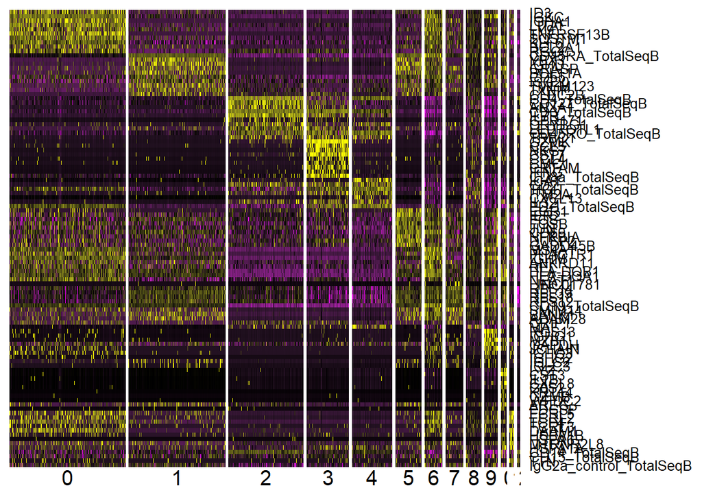

```r
top10 <- markers %>% group_by(cluster) %>% top_n(10, avg_logFC)
DoHeatmap(
    object = malt,
    genes.use = top10$gene,
    slim.col.label = TRUE,
    remove.key = TRUE
)
```

Visualizing marker genes:

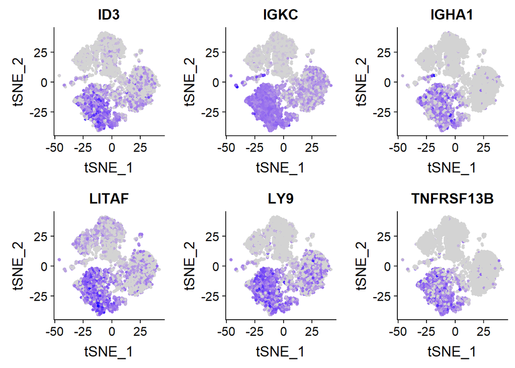

```r
FeaturePlot(
    malt,
    head(rownames(markers)),
    cols.use = c("lightgrey", "blue"),
    nCol = 3
)
```

Finally, comparing the differential expression tests used by Seurat, for cluster 1: (takes a long time to run)

```r
levels(malt@ident)
```

```
##  [1] "0"  "1"  "2"  "3"  "4"  "5"  "6"  "7"  "8"  "9"  "10" "11" "12"
```

```r
table(malt@ident)
```

```
##
##    0    1    2    3    4    5    6    7    8    9   10   11   12
## 2041 1699 1320  745  703  461  319  308  267  235  101   81   56
```

```r
my_bimod <- FindMarkers(object = malt,
                        ident.1 = 1,
                        thresh.use = 0.25,
                        test.use = "bimod",
                        only.pos = TRUE)

my_roc <- FindMarkers(object = malt,
                      ident.1 = 1,
                      thresh.use = 0.25,
                      test.use = "roc",
                      only.pos = TRUE)

my_t <- FindMarkers(object = malt,
                    ident.1 = 1,
                    thresh.use = 0.25,
                    test.use = "t",
                    only.pos = TRUE)

my_tobit <- FindMarkers(object = malt,
                        ident.1 = 1,
                        thresh.use = 0.25,
                        test.use = "tobit",
                        only.pos = TRUE)

# identical set of genes
dim(my_bimod)
```

```
## [1] 319   5
```

```r
dim(my_roc)
```

```
## [1] 319   7
```

```r
dim(my_t)
```

```
## [1] 319   5
```

```r
dim(my_tobit)
```

```
## [1] 319   5
```

```r
my_gene <- row.names(my_bimod)
a <- 1:length(my_gene)
b <- match(my_gene, row.names(my_roc))
c <- match(my_gene, row.names(my_t))
d <- match(my_gene, row.names(my_tobit))

# bimod vs. bimod
cor(a, a, method = "spearman")
```

```
## [1] 1
```

```r
# bimod vs. roc
cor(a, b, method = "spearman")
```

```
## [1] 0.8485431
```

```r
# bimod vs. t
cor(a, c, method = "spearman")
```

```
## [1] 0.859607
```

```r
# bimod vs. tobit
cor(a, d, method = "spearman")
```

```
## [1] 0.9462135
```

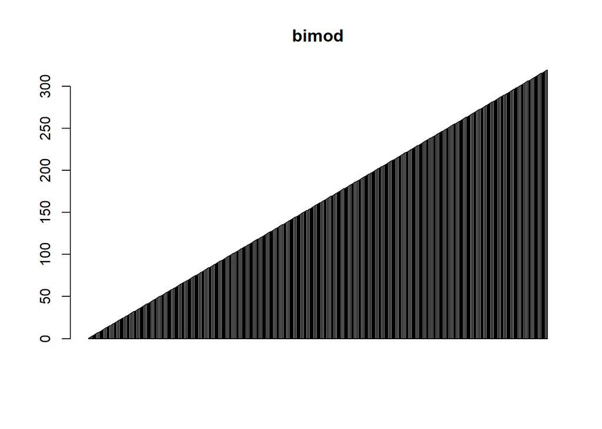

```r
barplot(a, main = 'bimod')
```

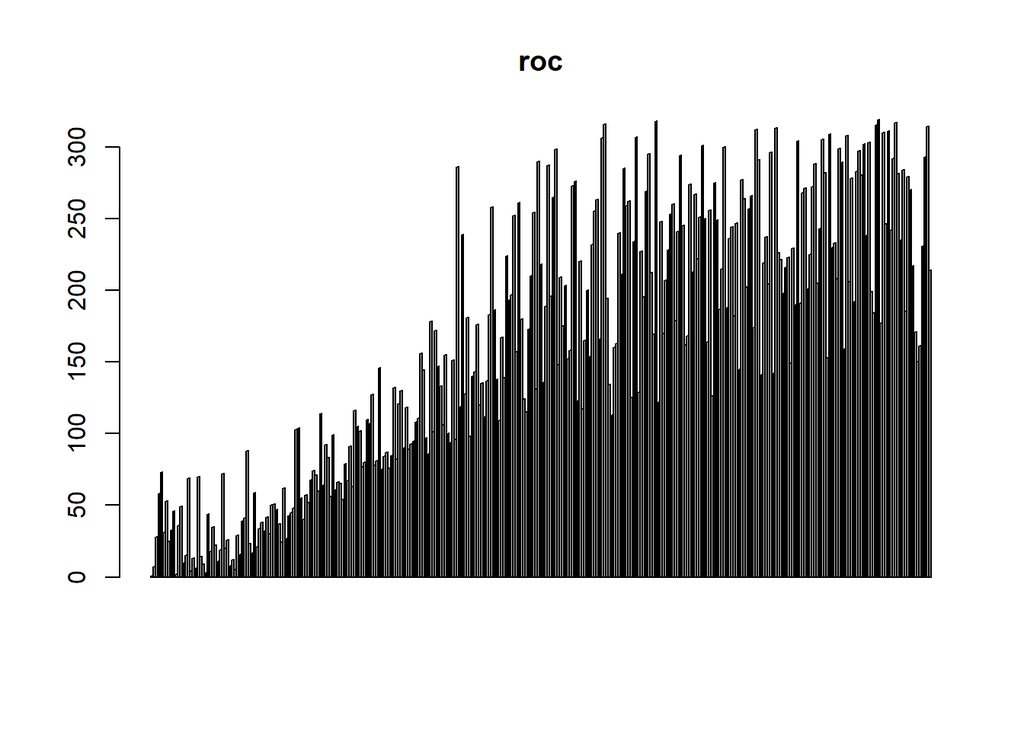

```r
barplot(b, main = 'roc')
```

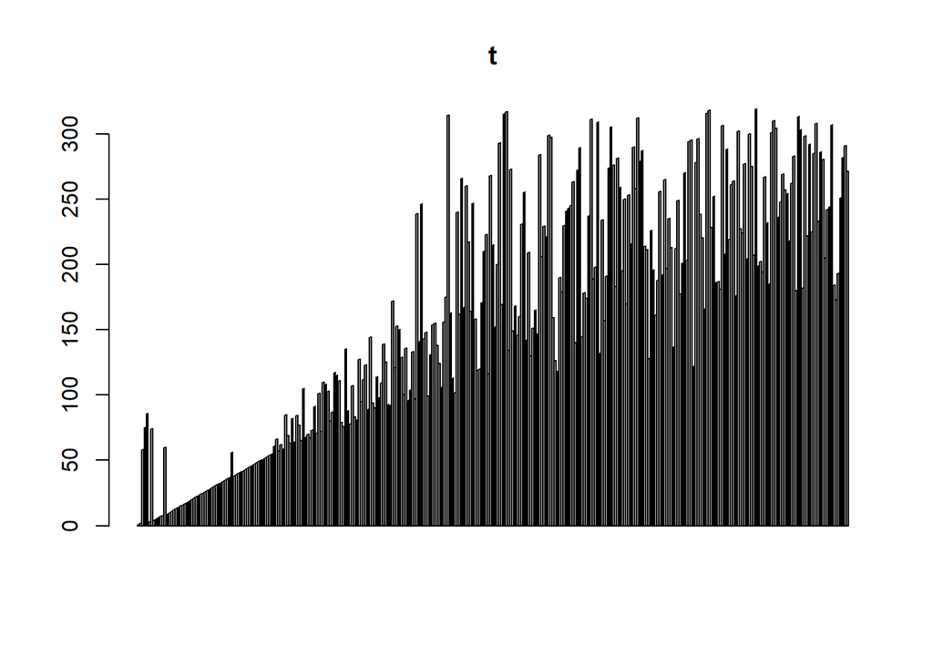

```r
barplot(c, main = 't')
```

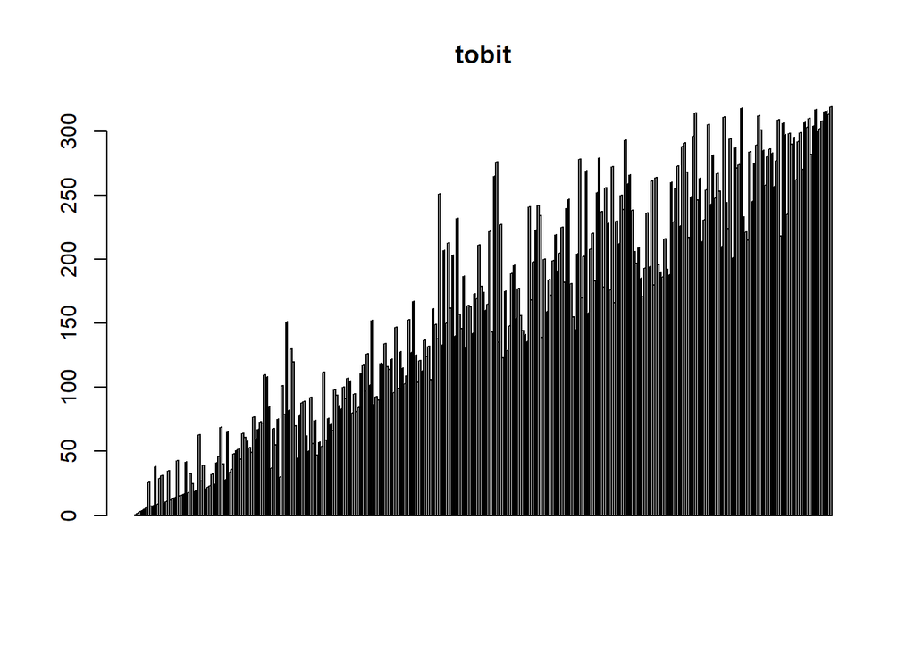

```r
barplot(d, main = 'tobit')
```